# RISE combined Aims 1 & 2

Mike Frank & My Vu

11/09/2026

# Read in data

| common column | meaning |
| --- | --- |
| `sub_id` | `response_uuid` |
| `age` | 6 or 12 months (already snapped in the Aim Rmds); factor with 6 as reference |
| `measure` | task outcome (see below) |
| `item` | trial / word pair, used as a crossed random intercept (NA where the Aim models don’t use one) |
| `stimulus_type` | VPC (Social / Non-social) and Numeracy (5- / 20-item stream) only |
| `block` | Prediction only (Block 1 / Block 2) |

Outcomes:

- Geosocial: Outcome is % frames looking at social stimulus (`target_prop`).
- VPC: Outcome is % frames looking at novel stimulus (`target_prop`).
- AV: Outcome is % frames looking at synchronous stimulus (`target_prop`).
- Prediction: Outcome is proportion of trials with an AEM, per participant per block (`aem_prop`).
- Word Comprehension: Outcome is % target - % distracter (`diff`), per participant per word pair.
- Numeracy: Outcome is % frames looking at changing stimulus (`target_prop`).
- Helper/Hinderer: Outcome is % frames looking at helping stimulus (`target_prop`; trials 7 and 14 only).

Recode: Age 6 is the reference level; Numeracy stimulus type uses the same labels as the Aim Rmds (Large Constant = 20-item stream, Small Constant = 5-item stream).

Plot.

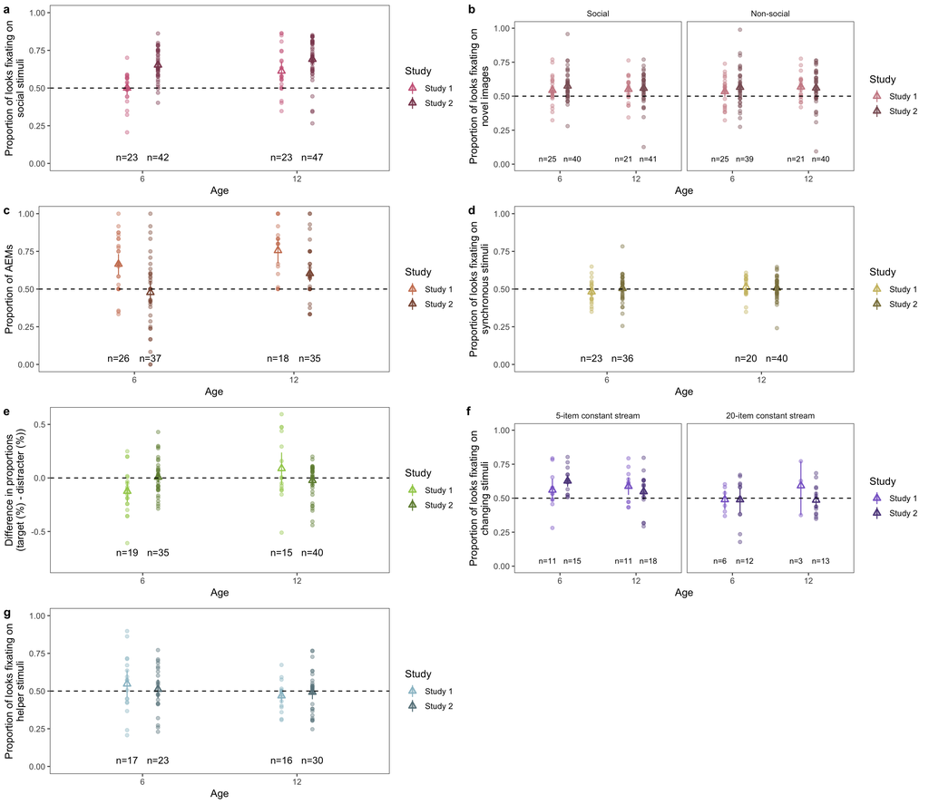

# Stats

All model output uses `run_condition_model()` (`models_func.R`), the same helper as the Aim 1 and Aim 2 Rmds: `lmerTest::lmer` with REML, emmeans estimates tested against chance, 95% CIs, `adjust = "none"`.

## Geosocial

Mixed model estimates for Geosocial (Age x Study)

| Condition | Estimate (95% CI) | P-value |
| --- | --- | --- |
| **Study 1** |  |  |
| Study 1 \| Overall | 0.56 (0.51, 0.62) | 0.024 |
| Study 1 \| Age 6 | 0.51 (0.44, 0.57) | 0.854 |
| Study 1 \| Age 12 | 0.62 (0.56, 0.68) | < 0.001 |
| Study 1 \| Age 12 - Age 6 | 0.11 (0.04, 0.19) | 0.002 |
| **Study 2** |  |  |
| Study 2 \| Overall | 0.68 (0.63, 0.73) | < 0.001 |
| Study 2 \| Age 6 | 0.66 (0.61, 0.71) | < 0.001 |
| Study 2 \| Age 12 | 0.70 (0.65, 0.75) | < 0.001 |
| Study 2 \| Age 12 - Age 6 | 0.04 (-0.01, 0.09) | 0.13 |
| **Interaction contrast** |  |  |
| Age 12 - Age 6 \| Study 1 - Study 2 | 0.08 (-0.01, 0.16) | 0.092 |

## VPC

Mixed model estimates for VPC (Age x Study x Stimulus type)

| Condition | Estimate (95% CI) | P-value |
| --- | --- | --- |
| **Study 1 \| Non-social** |  |  |
| Study 1 \| Non-social \| Overall | 0.55 (0.51, 0.58) | 0.006 |
| Study 1 \| Non-social \| Age 6 | 0.54 (0.50, 0.58) | 0.078 |
| Study 1 \| Non-social \| Age 12 | 0.56 (0.51, 0.61) | 0.016 |
| Study 1 \| Non-social \| Age 12 - Age 6 | 0.02 (-0.04, 0.08) | 0.516 |
| **Study 1 \| Social** |  |  |
| Study 1 \| Social \| Overall | 0.55 (0.51, 0.58) | 0.011 |
| Study 1 \| Social \| Age 6 | 0.54 (0.50, 0.58) | 0.071 |
| Study 1 \| Social \| Age 12 | 0.55 (0.50, 0.60) | 0.034 |
| Study 1 \| Social \| Age 12 - Age 6 | 0.01 (-0.05, 0.07) | 0.692 |
| **Study 2 \| Non-social** |  |  |
| Study 2 \| Non-social \| Overall | 0.56 (0.53, 0.59) | < 0.001 |
| Study 2 \| Non-social \| Age 6 | 0.55 (0.52, 0.59) | 0.006 |
| Study 2 \| Non-social \| Age 12 | 0.57 (0.53, 0.61) | < 0.001 |
| Study 2 \| Non-social \| Age 12 - Age 6 | 0.02 (-0.03, 0.07) | 0.408 |
| **Study 2 \| Social** |  |  |
| Study 2 \| Social \| Overall | 0.57 (0.54, 0.60) | < 0.001 |
| Study 2 \| Social \| Age 6 | 0.57 (0.54, 0.61) | < 0.001 |
| Study 2 \| Social \| Age 12 | 0.57 (0.53, 0.61) | < 0.001 |
| Study 2 \| Social \| Age 12 - Age 6 | -0.00 (-0.05, 0.04) | 0.88 |
| **Interaction contrast** |  |  |
| Age 12 - Age 6 \| (Study 1 \| Non-social) - Study 1 \| Social | 0.01 (-0.07, 0.09) | 0.848 |
| Age 12 - Age 6 \| (Study 1 \| Non-social) - (Study 2 \| Non-social) | 0.00 (-0.08, 0.08) | 0.994 |
| Age 12 - Age 6 \| (Study 1 \| Non-social) - Study 2 \| Social | 0.02 (-0.05, 0.10) | 0.542 |
| Age 12 - Age 6 \| Study 1 \| Social - (Study 2 \| Non-social) | -0.01 (-0.08, 0.07) | 0.842 |
| Age 12 - Age 6 \| Study 1 \| Social - Study 2 \| Social | 0.02 (-0.06, 0.09) | 0.685 |
| Age 12 - Age 6 \| (Study 2 \| Non-social) - Study 2 \| Social | 0.02 (-0.04, 0.09) | 0.466 |

## Audiovisual

No stimulus type in either study’s AV data (the Aim models are age only).

Mixed model estimates for Audiovisual (Age x Study)

| Condition | Estimate (95% CI) | P-value |
| --- | --- | --- |
| **Study 1** |  |  |
| Study 1 \| Overall | 0.49 (0.45, 0.54) | 0.796 |
| Study 1 \| Age 6 | 0.48 (0.43, 0.53) | 0.485 |
| Study 1 \| Age 12 | 0.51 (0.45, 0.56) | 0.796 |
| Study 1 \| Age 12 - Age 6 | 0.03 (-0.04, 0.10) | 0.464 |
| **Study 2** |  |  |
| Study 2 \| Overall | 0.51 (0.47, 0.54) | 0.73 |
| Study 2 \| Age 6 | 0.50 (0.47, 0.54) | 0.836 |
| Study 2 \| Age 12 | 0.51 (0.47, 0.54) | 0.719 |
| Study 2 \| Age 12 - Age 6 | 0.00 (-0.04, 0.05) | 0.902 |
| **Interaction contrast** |  |  |
| Age 12 - Age 6 \| Study 1 - Study 2 | 0.02 (-0.06, 0.11) | 0.574 |

## Prediction

Let’s first look across blocks and then within. Rows are participant x block (`aem_prop`).

Mixed model estimates for Prediction, across blocks (Age x Study)

| Condition | Estimate (95% CI) | P-value |
| --- | --- | --- |
| **Study 1** |  |  |
| Study 1 \| Overall | 0.71 (0.63, 0.78) | < 0.001 |
| Study 1 \| Age 6 | 0.67 (0.57, 0.76) | < 0.001 |
| Study 1 \| Age 12 | 0.75 (0.63, 0.87) | < 0.001 |
| Study 1 \| Age 12 - Age 6 | 0.09 (-0.06, 0.24) | 0.259 |
| **Study 2** |  |  |
| Study 2 \| Overall | 0.55 (0.49, 0.60) | 0.115 |
| Study 2 \| Age 6 | 0.50 (0.41, 0.58) | 0.91 |
| Study 2 \| Age 12 | 0.60 (0.52, 0.68) | 0.021 |
| Study 2 \| Age 12 - Age 6 | 0.10 (-0.01, 0.22) | 0.083 |
| **Interaction contrast** |  |  |
| Age 12 - Age 6 \| Study 1 - Study 2 | -0.02 (-0.21, 0.17) | 0.871 |

Mixed model estimates for Prediction (Age x Study x Block)

| Condition | Estimate (95% CI) | P-value |
| --- | --- | --- |
| **Study 1 \| Block 1** |  |  |
| Study 1 \| Block 1 \| Overall | 0.63 (0.53, 0.73) | 0.013 |
| Study 1 \| Block 1 \| Age 6 | 0.57 (0.44, 0.70) | 0.287 |
| Study 1 \| Block 1 \| Age 12 | 0.69 (0.53, 0.84) | 0.019 |
| Study 1 \| Block 1 \| Age 12 - Age 6 | 0.12 (-0.09, 0.32) | 0.26 |
| **Study 1 \| Block 2** |  |  |
| Study 1 \| Block 2 \| Overall | 0.79 (0.69, 0.90) | < 0.001 |
| Study 1 \| Block 2 \| Age 6 | 0.76 (0.63, 0.89) | < 0.001 |
| Study 1 \| Block 2 \| Age 12 | 0.83 (0.66, 0.99) | < 0.001 |
| Study 1 \| Block 2 \| Age 12 - Age 6 | 0.07 (-0.14, 0.28) | 0.539 |
| **Study 2 \| Block 1** |  |  |
| Study 2 \| Block 1 \| Overall | 0.45 (0.37, 0.53) | 0.189 |
| Study 2 \| Block 1 \| Age 6 | 0.38 (0.27, 0.49) | 0.028 |
| Study 2 \| Block 1 \| Age 12 | 0.52 (0.40, 0.63) | 0.759 |
| Study 2 \| Block 1 \| Age 12 - Age 6 | 0.14 (-0.02, 0.30) | 0.08 |
| **Study 2 \| Block 2** |  |  |
| Study 2 \| Block 2 \| Overall | 0.65 (0.57, 0.73) | < 0.001 |
| Study 2 \| Block 2 \| Age 6 | 0.62 (0.51, 0.73) | 0.039 |
| Study 2 \| Block 2 \| Age 12 | 0.68 (0.56, 0.79) | 0.002 |
| Study 2 \| Block 2 \| Age 12 - Age 6 | 0.06 (-0.10, 0.22) | 0.471 |
| **Interaction contrast** |  |  |
| Age 12 - Age 6 \| Study 1 \| Block 1 - Study 1 \| Block 2 | 0.05 (-0.24, 0.34) | 0.734 |
| Age 12 - Age 6 \| Study 1 \| Block 1 - Study 2 \| Block 1 | -0.03 (-0.28, 0.23) | 0.848 |
| Age 12 - Age 6 \| Study 1 \| Block 1 - Study 2 \| Block 2 | 0.06 (-0.20, 0.31) | 0.656 |
| Age 12 - Age 6 \| Study 1 \| Block 2 - Study 2 \| Block 1 | -0.08 (-0.34, 0.19) | 0.572 |
| Age 12 - Age 6 \| Study 1 \| Block 2 - Study 2 \| Block 2 | 0.01 (-0.26, 0.27) | 0.955 |
| Age 12 - Age 6 \| Study 2 \| Block 1 - Study 2 \| Block 2 | 0.08 (-0.14, 0.31) | 0.465 |

## Word comprehension

`item` = word pair (as in the Aim models). Chance is 0 for the target - distracter difference.

Mixed model estimates for Word comprehension (Age x Study)

| Condition | Estimate (95% CI) | P-value |
| --- | --- | --- |
| **Study 1** |  |  |
| Study 1 \| Overall | 0.07 (-0.04, 0.17) | 0.192 |
| Study 1 \| Age 6 | -0.04 (-0.17, 0.09) | 0.547 |
| Study 1 \| Age 12 | 0.18 (0.04, 0.32) | 0.014 |
| Study 1 \| Age 12 - Age 6 | 0.22 (0.04, 0.39) | 0.016 |
| **Study 2** |  |  |
| Study 2 \| Overall | 0.00 (-0.06, 0.06) | 0.933 |
| Study 2 \| Age 6 | 0.00 (-0.06, 0.07) | 0.894 |
| Study 2 \| Age 12 | -0.00 (-0.06, 0.06) | 1 |
| Study 2 \| Age 12 - Age 6 | -0.00 (-0.08, 0.07) | 0.912 |
| **Interaction contrast** |  |  |
| Age 12 - Age 6 \| Study 1 - Study 2 | 0.22 (0.03, 0.41) | 0.023 |

## Numeracy

Also a stimulus type interaction.

Mixed model estimates for Numeracy (Age x Study)

| Condition | Estimate (95% CI) | P-value |
| --- | --- | --- |
| **Study 1** |  |  |
| Study 1 \| Overall | 0.57 (0.51, 0.63) | 0.028 |
| Study 1 \| Age 6 | 0.54 (0.47, 0.61) | 0.299 |
| Study 1 \| Age 12 | 0.60 (0.52, 0.68) | 0.015 |
| Study 1 \| Age 12 - Age 6 | 0.06 (-0.04, 0.16) | 0.211 |
| **Study 2** |  |  |
| Study 2 \| Overall | 0.55 (0.50, 0.61) | 0.059 |
| Study 2 \| Age 6 | 0.57 (0.51, 0.63) | 0.026 |
| Study 2 \| Age 12 | 0.53 (0.47, 0.59) | 0.248 |
| Study 2 \| Age 12 - Age 6 | -0.04 (-0.11, 0.03) | 0.312 |
| **Interaction contrast** |  |  |
| Age 12 - Age 6 \| Study 1 - Study 2 | 0.10 (-0.02, 0.22) | 0.11 |

Mixed model estimates for Numeracy (Age x Study x Stimulus type)

| Condition | Estimate (95% CI) | P-value |
| --- | --- | --- |
| **Study 1 \| 20-item constant stream** |  |  |
| Study 1 \| 20-item constant stream \| Overall | 0.56 (0.46, 0.66) | 0.25 |
| Study 1 \| 20-item constant stream \| Age 6 | 0.48 (0.37, 0.59) | 0.731 |
| Study 1 \| 20-item constant stream \| Age 12 | 0.63 (0.48, 0.79) | 0.09 |
| Study 1 \| 20-item constant stream \| Age 12 - Age 6 | 0.15 (-0.04, 0.34) | 0.109 |
| **Study 1 \| 5-item constant stream** |  |  |
| Study 1 \| 5-item constant stream \| Overall | 0.58 (0.51, 0.64) | 0.026 |
| Study 1 \| 5-item constant stream \| Age 6 | 0.56 (0.48, 0.65) | 0.13 |
| Study 1 \| 5-item constant stream \| Age 12 | 0.59 (0.50, 0.67) | 0.048 |
| Study 1 \| 5-item constant stream \| Age 12 - Age 6 | 0.02 (-0.09, 0.14) | 0.671 |
| **Study 2 \| 20-item constant stream** |  |  |
| Study 2 \| 20-item constant stream \| Overall | 0.49 (0.42, 0.55) | 0.725 |
| Study 2 \| 20-item constant stream \| Age 6 | 0.49 (0.40, 0.57) | 0.74 |
| Study 2 \| 20-item constant stream \| Age 12 | 0.49 (0.41, 0.57) | 0.848 |
| Study 2 \| 20-item constant stream \| Age 12 - Age 6 | 0.01 (-0.10, 0.12) | 0.914 |
| **Study 2 \| 5-item constant stream** |  |  |
| Study 2 \| 5-item constant stream \| Overall | 0.59 (0.54, 0.65) | 0.005 |
| Study 2 \| 5-item constant stream \| Age 6 | 0.63 (0.55, 0.70) | 0.001 |
| Study 2 \| 5-item constant stream \| Age 12 | 0.56 (0.49, 0.63) | 0.09 |
| Study 2 \| 5-item constant stream \| Age 12 - Age 6 | -0.07 (-0.16, 0.02) | 0.148 |
| **Interaction contrast** |  |  |
| Age 12 - Age 6 \| (Study 1 \| 20-item constant stream) - (Study 1 \| 5-item constant stream) | 0.13 (-0.09, 0.35) | 0.244 |
| Age 12 - Age 6 \| (Study 1 \| 20-item constant stream) - (Study 2 \| 20-item constant stream) | 0.15 (-0.07, 0.37) | 0.184 |
| Age 12 - Age 6 \| (Study 1 \| 20-item constant stream) - (Study 2 \| 5-item constant stream) | 0.22 (0.01, 0.43) | 0.039 |
| Age 12 - Age 6 \| (Study 1 \| 5-item constant stream) - (Study 2 \| 20-item constant stream) | 0.02 (-0.14, 0.18) | 0.821 |
| Age 12 - Age 6 \| (Study 1 \| 5-item constant stream) - (Study 2 \| 5-item constant stream) | 0.09 (-0.05, 0.24) | 0.213 |
| Age 12 - Age 6 \| (Study 2 \| 20-item constant stream) - (Study 2 \| 5-item constant stream) | 0.07 (-0.07, 0.22) | 0.312 |

## Helper hinderer

Mixed model estimates for Helper/Hinderer (Age x Study)

| Condition | Estimate (95% CI) | P-value |
| --- | --- | --- |
| **Study 1** |  |  |
| Study 1 \| Overall | 0.51 (0.46, 0.57) | 0.6 |
| Study 1 \| Age 6 | 0.56 (0.49, 0.63) | 0.094 |
| Study 1 \| Age 12 | 0.47 (0.39, 0.54) | 0.371 |
| Study 1 \| Age 12 - Age 6 | -0.09 (-0.20, 0.01) | 0.072 |
| **Study 2** |  |  |
| Study 2 \| Overall | 0.50 (0.46, 0.54) | 0.98 |
| Study 2 \| Age 6 | 0.51 (0.45, 0.57) | 0.66 |
| Study 2 \| Age 12 | 0.49 (0.43, 0.54) | 0.652 |
| Study 2 \| Age 12 - Age 6 | -0.03 (-0.11, 0.05) | 0.53 |
| **Interaction contrast** |  |  |
| Age 12 - Age 6 \| Study 1 - Study 2 | -0.07 (-0.20, 0.06) | 0.292 |